# Eat or Not to Eat? Uncovering Survival Rules in the Mushroom Kingdom

*Adam Jaworski*

## Introduction

Foraging for wild mushrooms is a popular pastime rooted in tradition, but it carries a lethal risk. The distinction between a culinary delicacy and a deadly meal can often hang on subtle physical characteristics like the shape of the stalk, the color of the gills, or a specific odor. While modern machine learning often focuses on prediction, this project is focused on discovery. The interest is not in a model that classifies a mushroom as poisonous. Rather, the aim is to understand the explicit rules of nature that determine toxicity and also factors signaling edibility.

```python
import pandas as pd
import warnings
from src.data_loader import load_data, drop_constant_columns
from src.map import apply_mappings
from src.model import get_association_rules
from src.visualisation import *

warnings.filterwarnings('ignore')
pd.set_option('display.max_columns', None)
pd.set_option('display.max_colwidth', 100)
```

## Data description

The analysis is based on the [UCI Mushroom Data Set](https://archive.ics.uci.edu/dataset/73/mushroom). It includes descriptions of hypothetical samples corresponding to 23 species of gilled mushrooms in the Agaricus and Lepiota Family.

- **Observations:** 8,124 instances.
- **Features:** 22 categorical attributes (e.g., cap-shape, gill-color, habitat) + class attribute.
- **Target:** Classification (Edible vs. Poisonous).

```python
raw_df = load_data('data/mushrooms_raw.csv')

# converting single letters (e.g., 'b', 'x') to descriptive names (e.g., 'bell', 'convex')
mapped_df = apply_mappings(raw_df)

# data cleaning - removing columns with zero variance as they do not contribute to rule generation
clean_df = drop_constant_columns(mapped_df)

print(f"Data ready for analysis. Shape: {clean_df.shape}")
clean_df.head()
```

```
Loading data from local file: data/mushrooms_raw.csv
[Data Cleaning] Dropping constant columns (no information): ['veil-type']
Data ready for analysis. Shape: (8124, 22)
```

|  | cap-shape | cap-surface | cap-color | bruises | odor | gill-attachment | gill-spacing | gill-size | gill-color | stalk-shape | stalk-root | stalk-surface-above-ring | stalk-surface-below-ring | stalk-color-above-ring | stalk-color-below-ring | veil-color | ring-number | ring-type | spore-print-color | population | habitat | poisonous |
| --- | --- | --- | --- | --- | --- | --- | --- | --- | --- | --- | --- | --- | --- | --- | --- | --- | --- | --- | --- | --- | --- | --- |
| 0 | convex | smooth | brown | bruises | pungent | free | close | narrow | black | enlarging | equal | smooth | smooth | white | white | white | one | pendant | black | scattered | urban | poisonous |
| 1 | convex | smooth | yellow | bruises | almond | free | close | broad | black | enlarging | club | smooth | smooth | white | white | white | one | pendant | brown | numerous | grasses | edible |
| 2 | bell | smooth | white | bruises | anise | free | close | broad | brown | enlarging | club | smooth | smooth | white | white | white | one | pendant | brown | numerous | meadows | edible |
| 3 | convex | scaly | white | bruises | pungent | free | close | narrow | brown | enlarging | equal | smooth | smooth | white | white | white | one | pendant | black | scattered | urban | poisonous |
| 4 | convex | smooth | gray | no | none | free | crowded | broad | black | tapering | equal | smooth | smooth | white | white | white | one | evanescent | brown | abundant | grasses | edible |

## Exploratory Data Analysis

Before applying any algorithm, it is crucial to understand the underlying structure of the data. In Association Rule Mining, the frequency of items (*Support*) is a key parameter. If the dataset were heavily imbalanced (e.g., 99% edible mushrooms), detecting patterns for the minority class would require extremely low support thresholds, increasing the computational cost and noise.

We first examine the distribution of the target variable.

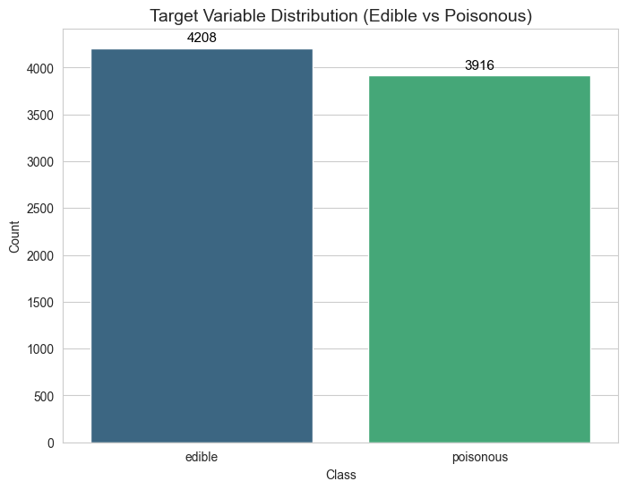

```python
plot_class_balance(clean_df)
```

The dataset is remarkably well-balanced, with a near-even split between **edible** and **poisonous** samples.

Strong odor is often associated with non-edibility of the mushroom. While visual features can be deceptive, distinct smells (like almond, anise, or foul odors) are often strongly correlated with specific chemical compounds. Visualization of the distribution of the `odor` feature is shown below to see which scent profiles are most common in the dataset:

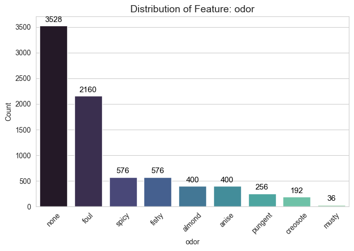

```python
plot_feature_distribution(clean_df, 'odor')
```

The distribution reveals that 'none' (no smell) and 'foul' (rotten smell) are the most frequent categories. The 'foul' odor is expected to be a strong antecedent in rules predicting toxicity. Conversely, scents like 'almond' or 'anise' might be strong indicators of edibility.

For a casual forager, visual cues are the primary method of identification. However, relying solely on color is notoriously dangerous. The distribution of `cap-color` can be useful to understand the variety present in the dataset.

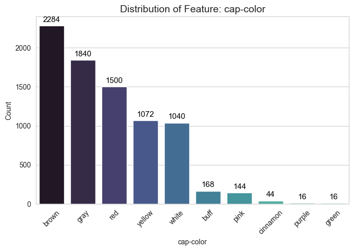

```python
plot_feature_distribution(clean_df, 'cap-color')
```

The correlation between categories is checked too. This step serves two purposes: identifying features that are strongly associated with the target class `poisonous` (potential best predictors) and detecting features that are strongly correlated with each other.

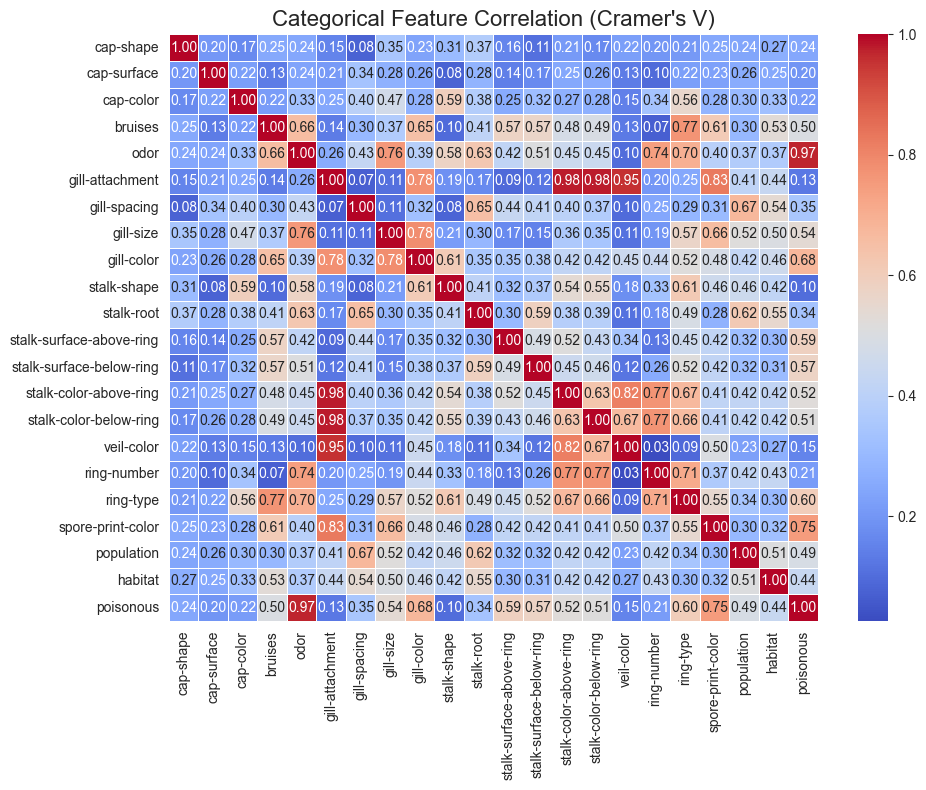

```python
corr_matrix = plot_correlation_heatmap(clean_df)
```

The heatmap reveals pockets of high correlation between certain structural features. High values between features (e.g., `gill-attachment` and `veil-color`) suggest that some physical characteristics biologically co-occur. While this indicates redundancy, they are retain later in the analysis. There are also several features that show a moderate-to-strong association with the `poisonous` column, confirming that toxicity is not necessarily random but can be structurally determined.

## Association Rules Mining

The **Apriori algorithm** uses a "bottom-up" approach, where frequent subsets are extended one item at a time. It relies on the property of the algorithm:

> *All non-empty subsets of a frequent itemset must also be frequent.* This property allows the algorithm to significantly reduce the search space. If a specific feature is rare, then any combination containing that feature is guaranteed to be equally rare or rarer, and thus can be ignored.

The Apriori algorithm is used to find frequent itemsets and generate association rules. The algorithm identifies frequent itemsets and generate rules in the format of:

> *IF {Antecedent} THEN {Consequent}*

For example: *"IF the odor is foul AND the stalk color is silky, THEN the mushroom is poisonous."*

**Evaluation Metrics:**

The strength and significance of the generated rules is evaluated using three standard metrics: **Support**, **Confidence**, and **Lift**.

1. **Support (Frequency)**: It indicates how frequently the itemset appears in the dataset - measures the popularity of a rule. A high support threshold ensures we are discovering general patterns applicable to a significant portion of the mushroom population, rather than rare anomalies. $$\text{Support}(X) = \frac{\text{Count(X)}}{\text{N}}$$
2. **Confidence (Reliability)** Confidence measures how often the rule has been found to be true. It is the conditional probability of the consequent ($Y$) given the antecedent ($X$). If a rule *"Odor=Foul $\rightarrow$ Class=Poisonous"* has a confidence of 1.0 (100%), it means that every single time a mushroom smelled foul in our dataset, it was poisonous. $$\text{Confidence}(X \rightarrow Y) = \frac{\text{Support}(X,Y)}{\text{Support}(X)}$$
3. **Lift (Strength of Association)** Lift measures how much more likely item $Y$ is to be purchased (or occur) when item $X$ is purchased, compared to when item $Y$ is purchased is isolation. It controls for the baseline popularity of $Y$. Lift is crucial because high confidence can sometimes be misleading if the consequent is extremely common (e.g., "If has stalk $\rightarrow$ Is Edible" might have high confidence just because most mushrooms are edible, not because the stalk implies it). $$\text{Lift}(X \rightarrow Y) = \frac{\text{Confidence}(X \rightarrow Y)}{\text{Support}(Y)}$$
- **Lift = 1:** The items are independent (no relationship).
- **Lift > 1:** Positive correlation (the presence of X increases the probability of Y).
- **Lift < 1:** Negative correlation (the presence of X decreases the probability of Y).

```python
# generate rules
rules_df = get_association_rules(clean_df, min_support=0.05, min_confidence=0.6, max_len=3)

print("Top 10 Rules by Support:")
rules_df.head(10)
```

```
Starting Association Rules Analysis (max_len=3)
Data encoded into 117 binary features.
Mining frequent itemsets with min_support=0.05...
Found 10202 frequent itemsets.
Generating rules with min_confidence=0.6...
Raw rules generated: 16791
Pruning: Removing 7956 redundant rules.
[Success] Final number of rules: 8835
Top 10 Rules by Support:
```

|  | antecedents | consequents | support | confidence | lift | antecedent_len |
| --- | --- | --- | --- | --- | --- | --- |
| 0 | gill-attachment=free | veil-color=white | 0.973166 | 0.998989 | 1.024203 | 1 |
| 1 | veil-color=white | gill-attachment=free | 0.973166 | 0.997728 | 1.024203 | 1 |
| 2 | gill-attachment=free | ring-number=one | 0.898080 | 0.921911 | 1.000214 | 1 |
| 3 | ring-number=one | gill-attachment=free | 0.898080 | 0.974359 | 1.000214 | 1 |
| 4 | ring-number=one | veil-color=white | 0.897095 | 0.973291 | 0.997856 | 1 |
| 5 | veil-color=white | ring-number=one | 0.897095 | 0.919738 | 0.997856 | 1 |
| 6 | gill-attachment=free | ring-number=one, veil-color=white | 0.897095 | 0.920900 | 1.026535 | 1 |
| 7 | ring-number=one | gill-attachment=free, veil-color=white | 0.897095 | 0.973291 | 1.000128 | 1 |
| 8 | veil-color=white | gill-attachment=free, ring-number=one | 0.897095 | 0.919738 | 1.024116 | 1 |
| 9 | ring-number=one, veil-color=white | gill-attachment=free | 0.897095 | 1.000000 | 1.026535 | 2 |

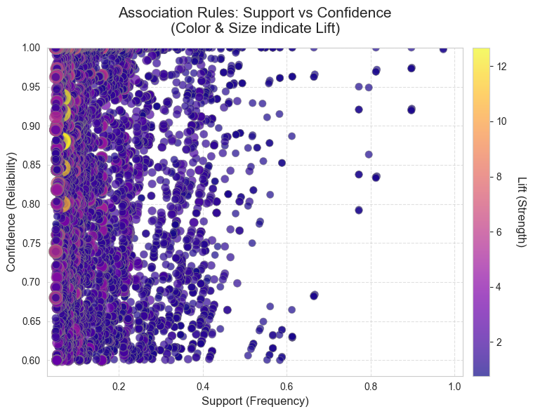

```python
plot_rules_scatter(rules_df)
```

The scatter plot below visualizes the relationship between the three key metrics for all generated rules.

- **X-axis (Support):** How common the rule is.
- **Y-axis (Confidence):** How accurate the rule is.
- **Color & Size (Lift):** The strength of the association.

Due to the low *support* treshold, most of rules are grouped near the Y-axis. There is also seen rise in *lift* as the dots are closer to Y-axis.

## Eat or not to eat?

This section separates findings into two categories:

1. **The Death Rules:** Indicators that guarantee toxicity.
2. **The Safe Bets:** Indicators that imply edibility with high confidence.

### Identifying Poisonous Mushrooms

From a safety perspective, generic correlations are insufficient. A forager needs guarantees. Specific safety question is asked: **Which characteristics guarantee that a mushroom is poisonous?**

```python
poison_rules = rules_df[
    (rules_df['consequents'] == 'poisonous=poisonous') &
    (rules_df['confidence'] >= 0.95)
]

print(f"Found {len(poison_rules)} high-confidence rules indicating toxicity.")
print("Examples of near-certain 'Death Rules':")
poison_rules[['antecedents', 'consequents', 'confidence', 'lift', 'support']].head(10)
```

```
Found 113 high-confidence rules indicating toxicity.
Examples of near-certain 'Death Rules':
```

|  | antecedents | consequents | confidence | lift | support |
| --- | --- | --- | --- | --- | --- |
| 1003 | gill-spacing=close, stalk-surface-above-ring=silky | poisonous=poisonous | 1.000000 | 2.074566 | 0.274249 |
| 1051 | ring-number=one, stalk-surface-above-ring=silky | poisonous=poisonous | 1.000000 | 2.074566 | 0.269818 |
| 1063 | odor=foul | poisonous=poisonous | 1.000000 | 2.074566 | 0.265879 |
| 1097 | stalk-surface-below-ring=silky, gill-spacing=close | poisonous=poisonous | 1.000000 | 2.074566 | 0.265879 |
| 1101 | stalk-surface-below-ring=silky, ring-number=one | poisonous=poisonous | 1.000000 | 2.074566 | 0.265879 |
| 1637 | spore-print-color=white, gill-size=narrow | poisonous=poisonous | 0.973684 | 2.019972 | 0.218612 |
| 1640 | spore-print-color=white, ring-number=one | poisonous=poisonous | 0.973684 | 2.019972 | 0.218612 |
| 1653 | ring-type=evanescent, gill-size=narrow | poisonous=poisonous | 0.973568 | 2.019732 | 0.217627 |
| 1683 | ring-type=evanescent, population=several | poisonous=poisonous | 0.973451 | 2.019489 | 0.216642 |
| 1686 | spore-print-color=white, population=several | poisonous=poisonous | 0.964912 | 2.001774 | 0.216642 |

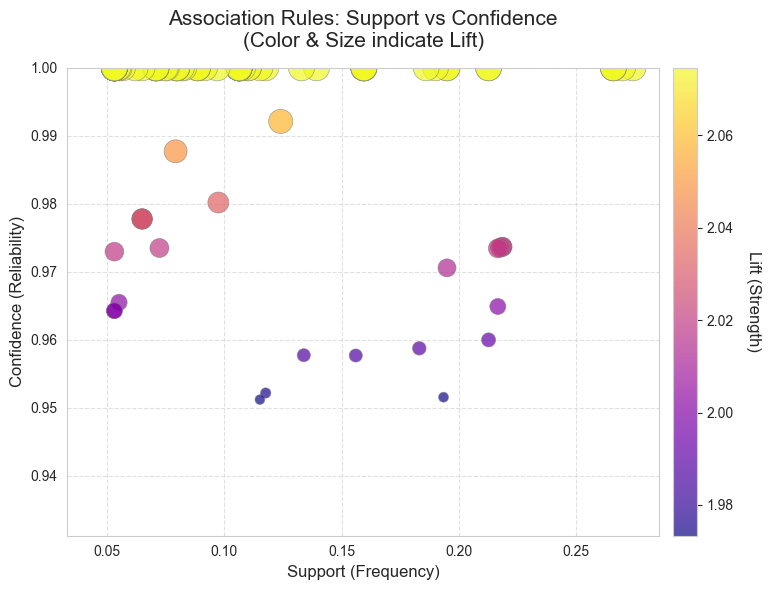

```python
plot_rules_scatter(poison_rules)
```

```python
poison_rules = rules_df[
    (rules_df['consequents'] == 'poisonous=poisonous') &
    (rules_df['confidence'] == 1)
]

print(f"Found {len(poison_rules)} certain rules indicating toxicity.")
print("Examples of certain 'Death Rules':")
poison_rules[['antecedents', 'consequents', 'confidence', 'lift', 'support']].head(10)
```

```
Found 89 certain rules indicating toxicity.
Examples of certain 'Death Rules':
```

|  | antecedents | consequents | confidence | lift | support |
| --- | --- | --- | --- | --- | --- |
| 1003 | gill-spacing=close, stalk-surface-above-ring=silky | poisonous=poisonous | 1.0 | 2.074566 | 0.274249 |
| 1051 | ring-number=one, stalk-surface-above-ring=silky | poisonous=poisonous | 1.0 | 2.074566 | 0.269818 |
| 1063 | odor=foul | poisonous=poisonous | 1.0 | 2.074566 | 0.265879 |
| 1097 | stalk-surface-below-ring=silky, gill-spacing=close | poisonous=poisonous | 1.0 | 2.074566 | 0.265879 |
| 1101 | stalk-surface-below-ring=silky, ring-number=one | poisonous=poisonous | 1.0 | 2.074566 | 0.265879 |
| 1722 | gill-color=buff | poisonous=poisonous | 1.0 | 2.074566 | 0.212703 |
| 1938 | spore-print-color=white, stalk-shape=tapering | poisonous=poisonous | 1.0 | 2.074566 | 0.212703 |
| 2234 | spore-print-color=chocolate, gill-size=broad | poisonous=poisonous | 1.0 | 2.074566 | 0.194978 |
| 2238 | stalk-root=bulbous, spore-print-color=chocolate | poisonous=poisonous | 1.0 | 2.074566 | 0.194978 |
| 2306 | population=several, stalk-surface-above-ring=silky | poisonous=poisonous | 1.0 | 2.074566 | 0.190054 |

There are a lot of rules indicating toxicity. Here are some of the easiest to remeber or to spot by a forager:

- **Smell:** the analysis confirms hypothesis stated earlier regarding `Odor`. The rule `If Odor = Foul -> Then Poisonous` appears with 100% confidence and relatively high support. This mathematically confirms that in this dataset, a foul smell is a definitive, non-negotiable indicator of toxicity.
- **Visual Warnings:** the algorithm identified that `gill-color=buff` (a yellowish-beige tone) is a highly reliable indicator of toxicity in this dataset. Another 100% effective rule relatively easy to spot in the forest involves `stalk-surface-above-ring=silky` or `stalk-surface-below-ring=silky` combined with `gill-spacing=close` or `ring-number=one`.

### Identifying Edible Mushrooms

Finding edible mushrooms is equally important. The same logic was impied to find antecedents that guarantee edibility.

The rules are filtered to find those where:

1. The consequent is **'poisonous=edible'**.
2. The confidence is above **0.95 (95%)**. - safe bet
3. The confidence is **1.00 (100%)**. - for certaintity

```python
edible_rules = rules_df[
    (rules_df['consequents'] == 'poisonous=edible') &
    (rules_df['confidence'] >= 0.95)
]

print(f"Found {len(edible_rules)} high-confidence rules indicating edibility.")
print("Examples of almost 'Safe Rules':")
edible_rules[['antecedents', 'consequents', 'confidence', 'lift', 'support']].head(10)
```

```
Found 93 high-confidence rules indicating edibility.
Examples of almost 'Safe Rules':
```

|  | antecedents | consequents | confidence | lift | support |
| --- | --- | --- | --- | --- | --- |
| 250 | odor=none | poisonous=edible | 0.965986 | 1.864941 | 0.419498 |
| 379 | gill-size=broad, odor=none | poisonous=edible | 0.978102 | 1.888332 | 0.395864 |
| 380 | veil-color=white, odor=none | poisonous=edible | 0.966346 | 1.865636 | 0.395864 |
| 574 | ring-number=one, odor=none | poisonous=edible | 0.983607 | 1.898959 | 0.354505 |
| 600 | stalk-surface-above-ring=smooth, odor=none | poisonous=edible | 0.972603 | 1.877715 | 0.349581 |
| 643 | stalk-surface-below-ring=smooth, odor=none | poisonous=edible | 0.972145 | 1.876831 | 0.343673 |
| 838 | stalk-shape=tapering, odor=none | poisonous=edible | 1.000000 | 1.930608 | 0.307238 |
| 905 | ring-type=pendant, odor=none | poisonous=edible | 0.967105 | 1.867102 | 0.289513 |
| 1485 | bruises=bruises, habitat=woods | poisonous=edible | 1.000000 | 1.930608 | 0.224520 |
| 1621 | habitat=woods, odor=none | poisonous=edible | 0.982379 | 1.896589 | 0.219596 |

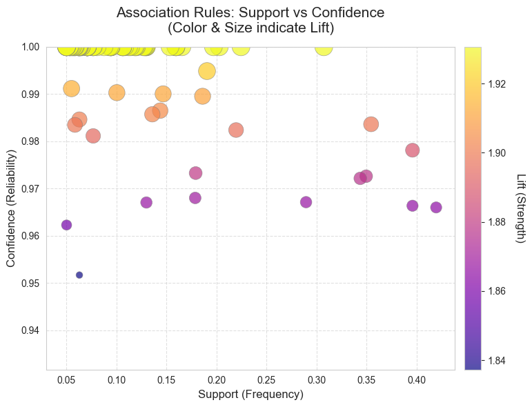

```python
plot_rules_scatter(edible_rules)
```

```python
edible_rules = rules_df[
    (rules_df['consequents'] == 'poisonous=edible') &
    (rules_df['confidence'] == 1)
]

print(f"Found {len(edible_rules)} certain rules indicating edibility.")
print("Examples of 'Safe Rules':")
edible_rules[['antecedents', 'consequents', 'confidence', 'lift', 'support']].head(10)
```

```
Found 70 certain rules indicating edibility.
Examples of 'Safe Rules':
```

|  | antecedents | consequents | confidence | lift | support |
| --- | --- | --- | --- | --- | --- |
| 838 | stalk-shape=tapering, odor=none | poisonous=edible | 1.0 | 1.930608 | 0.307238 |
| 1485 | bruises=bruises, habitat=woods | poisonous=edible | 1.0 | 1.930608 | 0.224520 |
| 2040 | spore-print-color=brown, gill-size=broad | poisonous=edible | 1.0 | 1.930608 | 0.202856 |
| 2110 | spore-print-color=black, gill-size=broad | poisonous=edible | 1.0 | 1.930608 | 0.196947 |
| 2678 | spore-print-color=brown, odor=none | poisonous=edible | 1.0 | 1.930608 | 0.165436 |
| 2958 | cap-surface=fibrous, stalk-shape=tapering | poisonous=edible | 1.0 | 1.930608 | 0.159527 |
| 3022 | spore-print-color=black, odor=none | poisonous=edible | 1.0 | 1.930608 | 0.159527 |
| 3065 | spore-print-color=brown, stalk-shape=tapering | poisonous=edible | 1.0 | 1.930608 | 0.159527 |
| 3211 | stalk-shape=tapering, spore-print-color=black | poisonous=edible | 1.0 | 1.930608 | 0.153619 |
| 3569 | gill-spacing=crowded, gill-size=broad | poisonous=edible | 1.0 | 1.930608 | 0.129985 |

```python
edible_rules[edible_rules['antecedent_len'] == 1][['antecedents', 'consequents', 'confidence', 'lift', 'support']].head(10)
```

|  | antecedents | consequents | confidence | lift | support |
| --- | --- | --- | --- | --- | --- |
| 6051 | stalk-color-above-ring=gray | poisonous=edible | 1.0 | 1.930608 | 0.070901 |
| 6056 | stalk-color-below-ring=gray | poisonous=edible | 1.0 | 1.930608 | 0.070901 |

- **One-factor predictors:** Interestingly, there are only two certain rules (Confidence = 1.0) that are have only one antecedent and they are not that frequent. Both of them are visual ones - `stalk-color-below-ring=gray` and `stalk-color-above-ring=gray`.

## Conclusion

In this project, the explicit rules that determine mushroom toxicity were uncovered. By applying Association Rule Mining (Apriori Algorithm) to the UCI Mushroom Data Set, high-confidence patterns that can serve as a practical guide for foraging safety were successfully extracted.